# Исследование рынка компьютерных игр

**Цели исследования:**

Провести анализ и обработку исторических данных о продажах игр, оценок и характеристик самих игр с целью:

- Выявить, закономерности которые позволят определять успешность игры для проведения рекламной кампании.
- Подготовить данные к предиктивному анализу успешности продаж для рекламной кампании.

**Ход исследования:**

Данные для исследования собраны из открытых источников и предоставляются в файле `games.csv`. С данными необходимо предварительно озанкомиться и оценить на предмет валидности и адекватности, также они, вероятно, требуют предобработки с целью устранения пропусков, ошибок и аномалий, после устранения которых будет возможен их исследовательский анализ.

Иследование будет включать в себя следующие шаги:

- Открытие и изучения файла
- Подготовка данных (исправление ошибок, аномалий и заполнение пропусков)
- Исследовательский анализ, включающий решение поставленных задач:
  - Оценка изменения выпуска игр по годам
  - Оценка изменения продаж игр по платформам
  - Оценка изменения продаж за актуальный период
  - Постороение диаграмм разброса ("ящиков с усами") для глобальных продаж
  - Изучение влияния отзывов пользователей и критиков на продажи внутри одной популярной платформы
  - Составление портрета пользователя каждого региона
- Проверка гипотез
  - Утверждение 1: Средние пользовательские рейтинги платформ Xbox One и PC одинаковые
  - Утверждение 2: Средние пользовательские рейтинги жанров Action и Sports разные
- Общие выводы

**Результаты исследования:**

- В рамках данного исследовательского проекта предоставленные данные о продажах игр были проанализированы и обработаны таким образом, что это позволяет их считать подготовленными к дальнейшему предиктивному анализу.
- Также данное исследование выявило тенденции и закономерности в данных, позволяющие сегментировать потенциальный рынок и подобрать игровой продукт для продвижения с помощью рекламной кампании.
- В соответствии с полученными выводами заказчику исследования были предоставлены рекомендации по выбору игрового продукта, оптимального по параметрам: жанра, региона, игровой платформы и возрастной группы ЦА, на котором следует сконцентрировать маркетинговые усилия.

## Открытие и предварительная обработка файла с данными, изучение общей информации

```python
import pandas as pd
import matplotlib.pyplot as plt
import numpy as np

from scipy import stats
```

```python
# чтобы таблицы не обрезались по ширине
pd.options.display.max_columns = 100
```

```python
games = pd.read_csv('/home/panther/Documents/Deep Learning/datasets/games.csv')
```

```python
games.head()
```

|  | Name | Platform | Year_of_Release | Genre | NA_sales | EU_sales | JP_sales | Other_sales | Critic_Score | User_Score | Rating |
| --- | --- | --- | --- | --- | --- | --- | --- | --- | --- | --- | --- |
| 0 | Wii Sports | Wii | 2006.0 | Sports | 41.36 | 28.96 | 3.77 | 8.45 | 76.0 | 8 | E |
| 1 | Super Mario Bros. | NES | 1985.0 | Platform | 29.08 | 3.58 | 6.81 | 0.77 | NaN | NaN | NaN |
| 2 | Mario Kart Wii | Wii | 2008.0 | Racing | 15.68 | 12.76 | 3.79 | 3.29 | 82.0 | 8.3 | E |
| 3 | Wii Sports Resort | Wii | 2009.0 | Sports | 15.61 | 10.93 | 3.28 | 2.95 | 80.0 | 8 | E |
| 4 | Pokemon Red/Pokemon Blue | GB | 1996.0 | Role-Playing | 11.27 | 8.89 | 10.22 | 1.00 | NaN | NaN | NaN |

```python
games.isna().agg(['sum', 'mean']).transpose()
```

|  | sum | mean |
| --- | --- | --- |
| Name | 2.0 | 0.000120 |
| Platform | 0.0 | 0.000000 |
| Year_of_Release | 269.0 | 0.016093 |
| Genre | 2.0 | 0.000120 |
| NA_sales | 0.0 | 0.000000 |
| EU_sales | 0.0 | 0.000000 |
| JP_sales | 0.0 | 0.000000 |
| Other_sales | 0.0 | 0.000000 |
| Critic_Score | 8578.0 | 0.513192 |
| User_Score | 6701.0 | 0.400897 |
| Rating | 6766.0 | 0.404786 |

Всего доля процента пропусков в `Name` и `Genre` и чуть меньше 2% в колонке `Year_of_Release`, пропуски в этих колонках можно удалить почти без ущерба для репрезентативности данных. В остальных колонках пропуски будут заполняться.

```python
games.info()
```

```
<class 'pandas.core.frame.DataFrame'>
RangeIndex: 16715 entries, 0 to 16714
Data columns (total 11 columns):
 #   Column           Non-Null Count  Dtype
---  ------           --------------  -----
 0   Name             16713 non-null  object
 1   Platform         16715 non-null  object
 2   Year_of_Release  16446 non-null  float64
 3   Genre            16713 non-null  object
 4   NA_sales         16715 non-null  float64
 5   EU_sales         16715 non-null  float64
 6   JP_sales         16715 non-null  float64
 7   Other_sales      16715 non-null  float64
 8   Critic_Score     8137 non-null   float64
 9   User_Score       10014 non-null  object
 10  Rating           9949 non-null   object
dtypes: float64(6), object(5)
memory usage: 1.4+ MB
```

```python
# поиск дубликатов

games.duplicated().sum()
```

```
0
```

## Подготовка данных

```python
# приведение названия столбцов к нижнему регистру

games.columns = games.columns.str.lower()
games.columns
```

```
Index(['name', 'platform', 'year_of_release', 'genre', 'na_sales', 'eu_sales',
       'jp_sales', 'other_sales', 'critic_score', 'user_score', 'rating'],
      dtype='object')
```

```python
# русские названия столбцов. Для графиков в проекте

ru_name = {'name': 'название игры', 'platform': 'платформа',
            'year_of_release': 'год выпуска', 'genre': 'жанр игры',
            'na_sales': 'продажи в Северной Америке', 'eu_sales': 'продажи в Европе',
            'jp_sales': 'продажи в Японии', 'other_sales': 'продажи в других странах',
            'critic_score': 'оценка критиков', 'user_score': 'оценка пользователей',
            'rating': 'рейтинг от организации ESRB', 'total_sales': 'глобальные продажи'
           }
```

Обработайте пропуски при необходимости: Объясните, почему заполнили пропуски определённым образом или почему не стали это делать; Опишите причины, которые могли привести к пропускам; Обратите внимание на аббревиатуру 'tbd' в столбце с оценкой пользователей. Отдельно разберите это значение и опишите, как его обработать;

### Исправление пропусков и аномальных значений

##### пропуски и аномальные значения в названиях игр (name)

```python
games['name'].describe()
```

```
count                           16713
unique                          11559
top       Need for Speed: Most Wanted
freq                               12
Name: name, dtype: object
```

Аномалии в названиях для исследования не важны, в исследовании эта колонка не участвует. Часто встречающиеся названия означают, что игра выходила сразу на нескольких платформах и иногда переиздавалась. То есть это не дубликаты:

```python
games[games['name'] == 'Need for Speed: Most Wanted'][['name', 'platform']]
```

|  | name | platform |
| --- | --- | --- |
| 253 | Need for Speed: Most Wanted | PS2 |
| 523 | Need for Speed: Most Wanted | PS3 |
| 1190 | Need for Speed: Most Wanted | X360 |
| 1591 | Need for Speed: Most Wanted | X360 |
| 1998 | Need for Speed: Most Wanted | XB |
| 2048 | Need for Speed: Most Wanted | PSV |
| 3581 | Need for Speed: Most Wanted | GC |
| 5972 | Need for Speed: Most Wanted | PC |
| 6273 | Need for Speed: Most Wanted | WiiU |
| 6410 | Need for Speed: Most Wanted | DS |
| 6473 | Need for Speed: Most Wanted | GBA |
| 11715 | Need for Speed: Most Wanted | PC |

```python
# переиздание 2012-го года от студии Criterion Game

games[(games['name'] == 'Need for Speed: Most Wanted') & (games['platform'] == 'X360')]
```

|  | name | platform | year_of_release | genre | na_sales | eu_sales | jp_sales | other_sales | critic_score | user_score | rating |
| --- | --- | --- | --- | --- | --- | --- | --- | --- | --- | --- | --- |
| 1190 | Need for Speed: Most Wanted | X360 | 2012.0 | Racing | 0.62 | 0.78 | 0.01 | 0.15 | 83.0 | 8.5 | T |
| 1591 | Need for Speed: Most Wanted | X360 | 2005.0 | Racing | 1.00 | 0.13 | 0.02 | 0.10 | 83.0 | 8.5 | T |

```python
# выкидываем пропуски в столбце name. В первом разделе проекта выяснилось, что пропусков здесь меньше процента

games = games[games['name'].notna()]
```

##### пропуски и аномальные значения в колонке платформ (platforms)

```python
games['platform'].value_counts(dropna=False)
```

```
platform
PS2     2161
DS      2151
PS3     1331
Wii     1320
X360    1262
PSP     1209
PS      1197
PC       974
XB       824
GBA      822
GC       556
3DS      520
PSV      430
PS4      392
N64      319
XOne     247
SNES     239
SAT      173
WiiU     147
2600     133
NES       98
GB        98
DC        52
GEN       27
NG        12
SCD        6
WS         6
3DO        3
TG16       2
GG         1
PCFX       1
Name: count, dtype: int64
```

Аномалий и пропусков нет.

##### пропуски и аномальные значения в колонке годов выпуска игр (year_of_release)

```python
# статистика по распределению лет в столбце

games['year_of_release'].describe()
```

```
count    16444.000000
mean      2006.486256
std          5.875525
min       1980.000000
25%       2003.000000
50%       2007.000000
75%       2010.000000
max       2016.000000
Name: year_of_release, dtype: float64
```

Аномальных значений не выявлено.

Для некоторых игр год выхода можно найти в названии самой игры, для таких пропуски заполним исходя из логики, что в названии игр помещается обычно год, следующий за годом выпуска. Так, например, игра FIFA 15 вышла в 2014-м году:

```python
games[games['name'] == 'FIFA 15']['year_of_release'].head(1)
```

```
143    2014.0
Name: year_of_release, dtype: float64
```

```python
# выделяю игры, которые в названии содержат от 2 до 4 цифр на последнем месте

g_w_years = games[(games['year_of_release'].isna()) & (games['name'].str.contains(r'[0-9]{2,4}$', na=False))]['name']
g_w_years
```

```
183                        Madden NFL 2004
377                       FIFA Soccer 2004
475             wwe Smackdown vs. Raw 2006
1301                        Triple Play 99
1650                   NASCAR Thunder 2003
2479                         Madden NFL 07
2492                    MLB SlugFest 20-03
2849                         Madden NFL 11
3413                         Madden NFL 06
3486                       Madden NFL 2002
4205               Tiger Woods PGA Tour 07
4775                      NFL GameDay 2003
5156                         NBA Live 2003
5655                All-Star Baseball 2005
5889                         NBA Live 2003
6266                              Indy 500
6954                               Jet X20
7605                            Famista 64
8918                All-Star Baseball 2005
13195                  Tour de France 2011
13929                      Sega Rally 2006
15953    PDC World Championship Darts 2008
16079                Football Manager 2007
16373    PDC World Championship Darts 2008
Name: name, dtype: object
```

```python
# вытаскиваю цифры длиной от 2 до 4-х символов из названий

years = g_w_years.str.extract(r'([0-9]{2,4})').astype(int).squeeze()
years
```

```
183      2004
377      2004
475      2006
1301       99
1650     2003
2479        7
2492       20
2849       11
3413        6
3486     2002
4205        7
4775     2003
5156     2003
5655     2005
5889     2003
6266      500
6954       20
7605       64
8918     2005
13195    2011
13929    2006
15953    2008
16079    2007
16373    2008
Name: 0, dtype: int64
```

По распределению лет минимальным годом выпуска в данных был 1980-й, максимальным - 2016-й, фильтрую данные исходя из этого:

```python
# несколько последовательно наложенных фильтров и коррекций

years[(years >= 80) & (years < 100)] = years + 1900
years[years < 1980] = years + 2000
years = years[years <= 2017]
years -= 1 # как правило в названиях игр указывается год, следующий за годом выхода игры

games.loc[years.index, 'year_of_release'] = years.values
games.iloc[years.index][['name', 'year_of_release']]
```

|  | name | year_of_release |
| --- | --- | --- |
| 183 | Madden NFL 2004 | 2003.0 |
| 377 | FIFA Soccer 2004 | 2003.0 |
| 475 | wwe Smackdown vs. Raw 2006 | 2005.0 |
| 1302 | Dragon Quest VII: Warriors of Eden | 2013.0 |
| 1651 | Cars | 2006.0 |
| 2480 | Time Crisis 4 | 2007.0 |
| 2850 | Super Monkey Ball Jr. | 2002.0 |
| 3414 | Asphalt: Urban GT | 2004.0 |
| 3487 | NCAA Football 10 | 2009.0 |
| 4206 | Art Academy: Lessons for Everyone | 2012.0 |
| 4776 | TNA iMPACT! | 2008.0 |
| 5157 | Fragile Dreams: Farewell Ruins of the Moon | 2009.0 |
| 5656 | The Conveni: Ano Machi wo Dokusen Seyo | 1997.0 |
| 5890 | Stranglehold | 2007.0 |
| 8919 | The Legend of Heroes: Trails of Cold Steel II | 2014.0 |
| 13196 | Durarara!! 3-way Standoff | 2010.0 |
| 13930 | TMNT | 2007.0 |
| 15955 | Kiss Bell | 2014.0 |
| 16081 | Dragon Zakura DS | 2007.0 |
| 16375 | Starry ? Sky: After Autumn | 2011.0 |

```python
# удаляю оставшиеся пропуски в колонке

games = games[games['year_of_release'].notna()]
```

##### пропуски и аномальные значения в колонкe жанров (genre)

```python
games['genre'].value_counts(dropna=False)
```

```
genre
Action          3307
Sports          2322
Misc            1721
Role-Playing    1481
Shooter         1296
Adventure       1293
Racing          1229
Platform         878
Simulation       857
Fighting         838
Strategy         673
Puzzle           569
Name: count, dtype: int64
```

Аномальных значений не обнаружено.

##### пропуски и аномальные значения в колонках продаж (na_sales, eu_sales, jp_sales, other_sales)

```python
games.loc[:, 'na_sales':'other_sales'].describe()
```

|  | na_sales | eu_sales | jp_sales | other_sales |
| --- | --- | --- | --- | --- |
| count | 16464.000000 | 16464.000000 | 16464.000000 | 16464.000000 |
| mean | 0.264409 | 0.146066 | 0.078398 | 0.047669 |
| std | 0.818592 | 0.506778 | 0.310922 | 0.188023 |
| min | 0.000000 | 0.000000 | 0.000000 | 0.000000 |
| 25% | 0.000000 | 0.000000 | 0.000000 | 0.000000 |
| 50% | 0.080000 | 0.020000 | 0.000000 | 0.010000 |
| 75% | 0.240000 | 0.110000 | 0.040000 | 0.030000 |
| max | 41.360000 | 28.960000 | 10.220000 | 10.570000 |

Подозрительно низкие минимальные и медианные продажи, для детализации нужны графики:

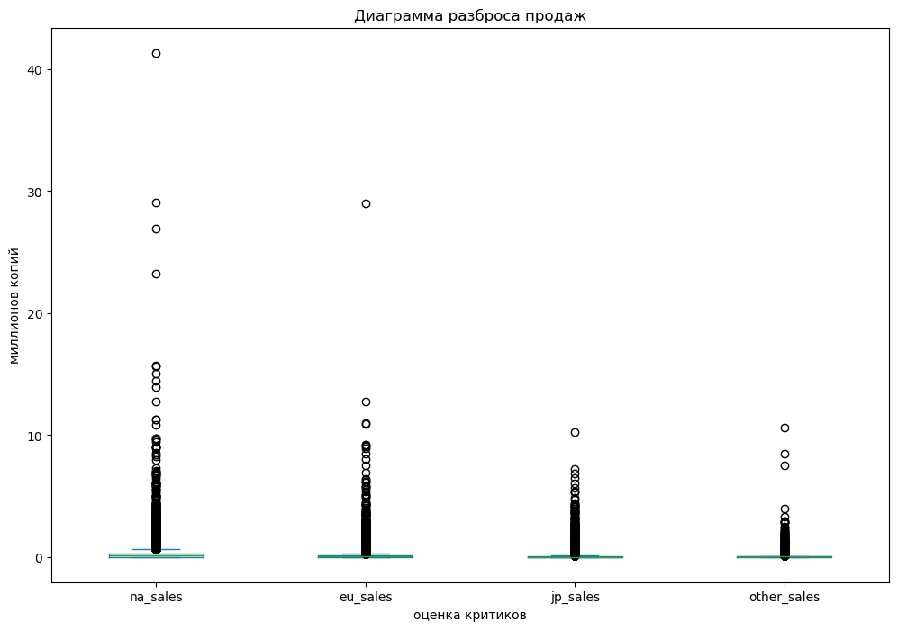

```python
# диаграммы разброса для продаж в разных регионах

games.loc[:, 'na_sales':'other_sales'].plot.box(
        xlabel=ru_name['critic_score'],
        ylabel='миллионов копий',
        title='Диаграмма разброса продаж',
        figsize=(12, 8)
    );
```

Видно, что это правоасимметричные распределения с пиком около нуля. Некоторые значения похожи на выбросы, но могут быть и просто низкочастотными отклонениями с высокими продажами. Проверяю это:

```python
# по визуальному анализу диаграммы разброса вывожу срез данных с подозрением на выбросы в каждой колонке

games[(games['na_sales'] > 20) | (games['eu_sales'] > 10) | (games['jp_sales'] > 8) | (games['other_sales'] > 5)]
```

|  | name | platform | year_of_release | genre | na_sales | eu_sales | jp_sales | other_sales | critic_score | user_score | rating |
| --- | --- | --- | --- | --- | --- | --- | --- | --- | --- | --- | --- |
| 0 | Wii Sports | Wii | 2006.0 | Sports | 41.36 | 28.96 | 3.77 | 8.45 | 76.0 | 8 | E |
| 1 | Super Mario Bros. | NES | 1985.0 | Platform | 29.08 | 3.58 | 6.81 | 0.77 | NaN | NaN | NaN |
| 2 | Mario Kart Wii | Wii | 2008.0 | Racing | 15.68 | 12.76 | 3.79 | 3.29 | 82.0 | 8.3 | E |
| 3 | Wii Sports Resort | Wii | 2009.0 | Sports | 15.61 | 10.93 | 3.28 | 2.95 | 80.0 | 8 | E |
| 4 | Pokemon Red/Pokemon Blue | GB | 1996.0 | Role-Playing | 11.27 | 8.89 | 10.22 | 1.00 | NaN | NaN | NaN |
| 5 | Tetris | GB | 1989.0 | Puzzle | 23.20 | 2.26 | 4.22 | 0.58 | NaN | NaN | NaN |
| 9 | Duck Hunt | NES | 1984.0 | Shooter | 26.93 | 0.63 | 0.28 | 0.47 | NaN | NaN | NaN |
| 10 | Nintendogs | DS | 2005.0 | Simulation | 9.05 | 10.95 | 1.93 | 2.74 | NaN | NaN | NaN |
| 17 | Grand Theft Auto: San Andreas | PS2 | 2004.0 | Action | 9.43 | 0.40 | 0.41 | 10.57 | 95.0 | 9 | M |
| 48 | Gran Turismo 4 | PS2 | 2004.0 | Racing | 3.01 | 0.01 | 1.10 | 7.53 | 89.0 | 8.5 | E |

По именитым названиям и распределению продаж видно, что это не выбросы, а хиты продаж. Подозрение вызывают только Duck Hunt и Grand Theft Auto: San Andreas. Но первый получил распространение в США (по данным википедии) потому что шел в комплекте поставки вместе с приставкой NES, а GTA в принципе популярна в первую очередь в США и имеет там культовый статус.

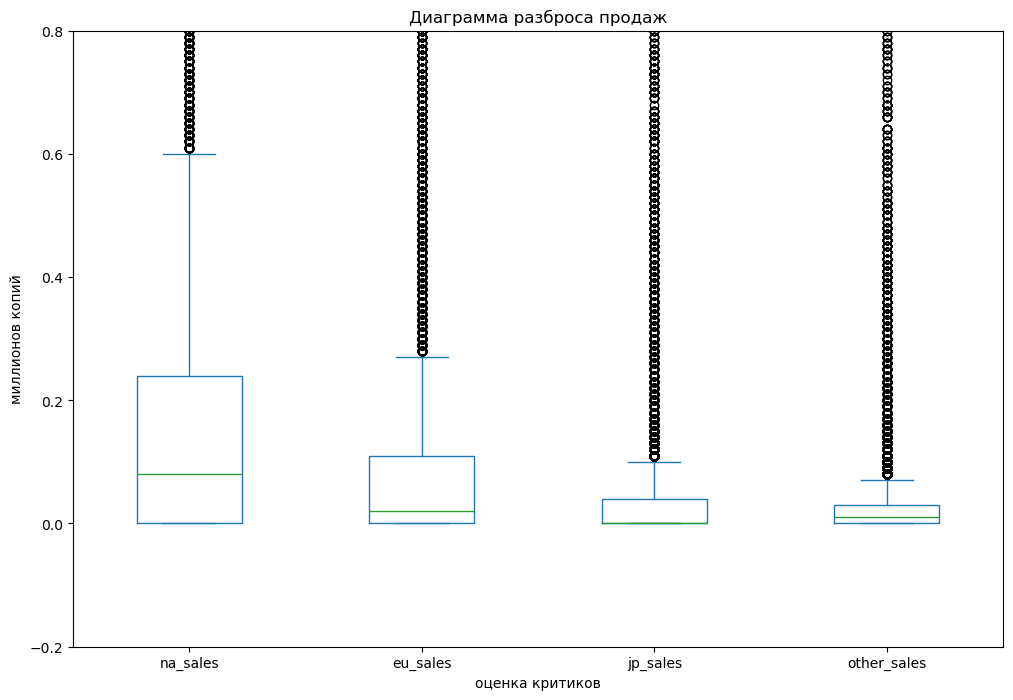

```python
# для детализаци увеличен масштаб

games.loc[:, 'na_sales':'other_sales'].plot.box(
        xlabel=ru_name['critic_score'],
        ylabel='миллионов копий',
        title='Диаграмма разброса продаж',
        ylim=(-0.2, 0.8),
        figsize=(12, 8)
    );
```

По виду диаграмм разброса видно, что большинство игр не продаются тиражами выше 200 тыс. копий, медианы сосредоточены в нижней половине "ящиков", ближе к нулю. По сравнению с максимальными значениями в десятки миллионов продаж - это показывает чрезвычайную концентрацию распределений в близкой к нулю части графиков, что означает, что выскими тиражами игры продаются крайне редко.

Аномальных значений в столбцах не обнаружено.

##### пропуски и аномальные значения в колонках оценок (critic_score, user_score)

Колонка `user_score` представлена типом object из-за наличия в ней текстовых значений 'tbd' (to be determined), которые означают, либо то, что пользовательских оценок на сайте-агрегаторе еще недостаточно для того, чтобы посчитать достоверное среднее значение оценок, либо что голосование еще не было открыто и оценок пользователей пока нет вообще.

Заменяю tbd на NaN, потому что tbd не несет информации о количестве баллов.

```python
games['user_score'].sort_values().unique()
```

```
array(['0', '0.2', '0.3', '0.5', '0.6', '0.7', '0.9', '1', '1.1', '1.2',
       '1.3', '1.4', '1.5', '1.6', '1.7', '1.8', '1.9', '2', '2.1', '2.2',
       '2.3', '2.4', '2.5', '2.6', '2.7', '2.8', '2.9', '3', '3.1', '3.2',
       '3.3', '3.4', '3.5', '3.6', '3.7', '3.8', '3.9', '4', '4.1', '4.2',
       '4.3', '4.4', '4.5', '4.6', '4.7', '4.8', '4.9', '5', '5.1', '5.2',
       '5.3', '5.4', '5.5', '5.6', '5.7', '5.8', '5.9', '6', '6.1', '6.2',
       '6.3', '6.4', '6.5', '6.6', '6.7', '6.8', '6.9', '7', '7.1', '7.2',
       '7.3', '7.4', '7.5', '7.6', '7.7', '7.8', '7.9', '8', '8.1', '8.2',
       '8.3', '8.4', '8.5', '8.6', '8.7', '8.8', '8.9', '9', '9.1', '9.2',
       '9.3', '9.4', '9.5', '9.6', '9.7', 'tbd', nan], dtype=object)
```

```python
games['critic_score'].sort_values().unique()
```

```
array([13., 17., 19., 20., 21., 23., 24., 25., 26., 27., 28., 29., 30.,
       31., 32., 33., 34., 35., 36., 37., 38., 39., 40., 41., 42., 43.,
       44., 45., 46., 47., 48., 49., 50., 51., 52., 53., 54., 55., 56.,
       57., 58., 59., 60., 61., 62., 63., 64., 65., 66., 67., 68., 69.,
       70., 71., 72., 73., 74., 75., 76., 77., 78., 79., 80., 81., 82.,
       83., 84., 85., 86., 87., 88., 89., 90., 91., 92., 93., 94., 95.,
       96., 97., 98., nan])
```

Заметно также, что оценки различаются на порядок, что означает разницу шкал (от 0 до 10 и от 0 до 100). Заменяю tbd и затем привожу оценки к общей шкале:

```python
games['user_score'] = games['user_score'].replace('tbd', np.nan)
```

```python
games['user_score'] = games['user_score'].astype('float')
games.loc[:, 'user_score'] = games['user_score'] * 10
```

```python
games.loc[:, ['critic_score','user_score']].describe().transpose()
```

|  | count | mean | std | min | 25% | 50% | 75% | max |
| --- | --- | --- | --- | --- | --- | --- | --- | --- |
| critic_score | 7998.0 | 69.003751 | 13.921967 | 13.0 | 60.0 | 71.0 | 79.0 | 98.0 |
| user_score | 7476.0 | 71.269797 | 14.991801 | 0.0 | 64.0 | 75.0 | 82.0 | 97.0 |

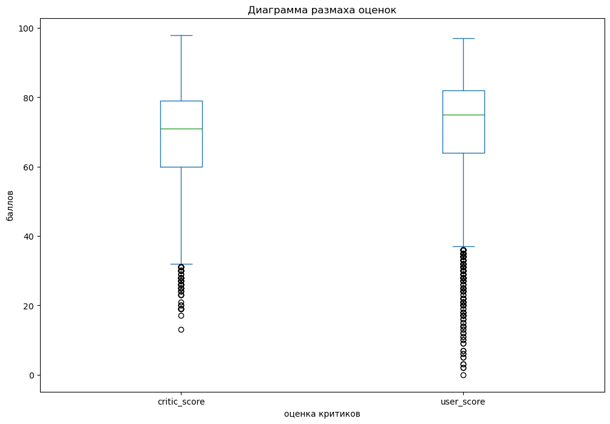

```python
games.loc[:, 'critic_score':'user_score'].plot.box(
    xlabel=ru_name['critic_score'],
    ylabel='баллов',
    title=f'Диаграмма размаха оценок',
    figsize=(12, 8)
);
```

```python
# пробелы заполняю нетипичным значением для оценок, находящимся вне пределов распределения

games['critic_score'] = games['critic_score'].fillna(-1)
games['user_score'] = games['user_score'].fillna(-1)
```

##### пропуски и аномальные значения в столбце рейтингов (rating)

```python
games['rating'].unique()
```

```
array(['E', nan, 'M', 'T', 'E10+', 'K-A', 'AO', 'EC', 'RP'], dtype=object)
```

Рейтинги K-A и EC - устаревшие и подпадающие в рейтинг E, произвожу замену:

```python
games.loc[(games['rating'] == 'K-A') | (games['rating'] == 'EC'), 'rating'] = 'E'
```

С рейтингом RP всего одна игра с околонулевыми продажами, эту строку тоже удаляю:

```python
games[games['rating'] == 'RP']
```

|  | name | platform | year_of_release | genre | na_sales | eu_sales | jp_sales | other_sales | critic_score | user_score | rating |
| --- | --- | --- | --- | --- | --- | --- | --- | --- | --- | --- | --- |
| 14270 | Supreme Ruler: Cold War | PC | 2011.0 | Strategy | 0.0 | 0.03 | 0.0 | 0.01 | 63.0 | 68.0 | RP |

```python
games = games[games['rating'] != 'RP']
```

Для дальнейшего анализа может понадобиться численно измеримая разница между значениями рейтинга, для этого "строковым" рейтингам вводится возрастное соответствие:

- E - everyone, - 3 года и старше (3);
- E10+ - everyone 10+, - все старше 10 (10);
- T - teenagers, - подростки от 13 (13);
- M - mature, зрелые (17);
- AO - adult only, взрослые (18);

```python
r_to_age = {'E': '3', 'E10+': '10', 'T': '13', 'M': '17', 'AO': '18'}
age_to_r = {'3': 'E', '10': 'E10+', '13': 'T', '17': 'M', '18': 'AO'}

# добавляю новую колонку с числовым возрастным рейтингом, показывающим минимальный допустимый возраст:
r_by_age = games.replace({'rating': r_to_age})['rating'].astype(float)
games.loc[:, 'rating_by_age'] = r_by_age
games.head()
```

|  | name | platform | year_of_release | genre | na_sales | eu_sales | jp_sales | other_sales | critic_score | user_score | rating | rating_by_age |
| --- | --- | --- | --- | --- | --- | --- | --- | --- | --- | --- | --- | --- |
| 0 | Wii Sports | Wii | 2006.0 | Sports | 41.36 | 28.96 | 3.77 | 8.45 | 76.0 | 80.0 | E | 3.0 |
| 1 | Super Mario Bros. | NES | 1985.0 | Platform | 29.08 | 3.58 | 6.81 | 0.77 | -1.0 | -1.0 | NaN | NaN |
| 2 | Mario Kart Wii | Wii | 2008.0 | Racing | 15.68 | 12.76 | 3.79 | 3.29 | 82.0 | 83.0 | E | 3.0 |
| 3 | Wii Sports Resort | Wii | 2009.0 | Sports | 15.61 | 10.93 | 3.28 | 2.95 | 80.0 | 80.0 | E | 3.0 |
| 4 | Pokemon Red/Pokemon Blue | GB | 1996.0 | Role-Playing | 11.27 | 8.89 | 10.22 | 1.00 | -1.0 | -1.0 | NaN | NaN |

Заполняю пробелы в `rating, rating_by_age` нетипичными значениями (заглушками):

```python
games.loc[games['rating'].isna(), ['rating', 'rating_by_age']] = ['Unknown', -1]
games.head()
```

|  | name | platform | year_of_release | genre | na_sales | eu_sales | jp_sales | other_sales | critic_score | user_score | rating | rating_by_age |
| --- | --- | --- | --- | --- | --- | --- | --- | --- | --- | --- | --- | --- |
| 0 | Wii Sports | Wii | 2006.0 | Sports | 41.36 | 28.96 | 3.77 | 8.45 | 76.0 | 80.0 | E | 3.0 |
| 1 | Super Mario Bros. | NES | 1985.0 | Platform | 29.08 | 3.58 | 6.81 | 0.77 | -1.0 | -1.0 | Unknown | -1.0 |
| 2 | Mario Kart Wii | Wii | 2008.0 | Racing | 15.68 | 12.76 | 3.79 | 3.29 | 82.0 | 83.0 | E | 3.0 |
| 3 | Wii Sports Resort | Wii | 2009.0 | Sports | 15.61 | 10.93 | 3.28 | 2.95 | 80.0 | 80.0 | E | 3.0 |
| 4 | Pokemon Red/Pokemon Blue | GB | 1996.0 | Role-Playing | 11.27 | 8.89 | 10.22 | 1.00 | -1.0 | -1.0 | Unknown | -1.0 |

### Преобразование типов данных

```python
games = games.astype({'year_of_release': 'int', 'critic_score': 'int',
                      'user_score': 'int', 'rating_by_age': 'int'}, errors='ignore')
games.dtypes
```

```
name                object
platform            object
year_of_release      int64
genre               object
na_sales           float64
eu_sales           float64
jp_sales           float64
other_sales        float64
critic_score         int64
user_score           int64
rating              object
rating_by_age        int64
dtype: object
```

### Суммарные продажи во всех регионах

```python
games['total_sales'] = games['na_sales'] + games['eu_sales'] + games['jp_sales'] + games['other_sales']
games.head()
```

|  | name | platform | year_of_release | genre | na_sales | eu_sales | jp_sales | other_sales | critic_score | user_score | rating | rating_by_age | total_sales |
| --- | --- | --- | --- | --- | --- | --- | --- | --- | --- | --- | --- | --- | --- |
| 0 | Wii Sports | Wii | 2006 | Sports | 41.36 | 28.96 | 3.77 | 8.45 | 76 | 80 | E | 3 | 82.54 |
| 1 | Super Mario Bros. | NES | 1985 | Platform | 29.08 | 3.58 | 6.81 | 0.77 | -1 | -1 | Unknown | -1 | 40.24 |
| 2 | Mario Kart Wii | Wii | 2008 | Racing | 15.68 | 12.76 | 3.79 | 3.29 | 82 | 83 | E | 3 | 35.52 |
| 3 | Wii Sports Resort | Wii | 2009 | Sports | 15.61 | 10.93 | 3.28 | 2.95 | 80 | 80 | E | 3 | 32.77 |
| 4 | Pokemon Red/Pokemon Blue | GB | 1996 | Role-Playing | 11.27 | 8.89 | 10.22 | 1.00 | -1 | -1 | Unknown | -1 | 31.38 |

### Выводы по подготовке данных:

Пропуски были обноружены в колонках `name, genre, year_of_release, critic_score, user_score, rating` и были заполнены.

В колонках `name, genre, year_of_release` пропуски скорее всего возникли либо из-за ошибок импорта данных, либо из-за неполноты данных в одном или нескольких источниках, откуда эти данные взяты. Пропуски в колонке `rating` скорее всего связаны с тем, что система возрастных рейтингов ESRB североамериканская, но ошибки или неполнота баз данных тоже могут быть среди причин. В колонках `critic_score, user_score` пропуски могут быть связаны как с неполнотой, так и с тем, что по многим играм просто не выходили материалы с оценками критиков, а оценок игроков не собиралось или их было недостаточно для формирования рейтинга. Значения tbd в колонке `user_score` отражают недостаток голосов для формирования оценки в каких-то источниках, из которых сформирован файл games.csv, в других источниках на месте tbd могли оказаться пропуски.

В колонке `year_of_release` некоторые пропуски были заполнены годами из названий игр, оставшиеся пропуски в колонках `name, genre, year_of_release` были удалены из-за незначительного их количества. В колонках `critic_score, user_score` пропуски были заменены нетипичными значениями вне пределов распределения (-1). Пропуски в колонке `rating` заполенены заглушкой 'Unknown'

В большинстве случаев некорректная интерпретация типов данных возникла из-за пропусков (*NaN* по умолчанию *float*, поэтому колонки, содержащие *NaN*, либо *float*, либо *object*). Но в колонке `user_score` некорректный тип был вызван значениями "tbd"

Колонка `user_score` была обработана с коррекцией значений tbd и коррекцией шкалы оценок. Колонки `critic_score, user_score, year_of_release` приведены к типу *int*

Аномальных значений в колонках найдено не было.

## Исследовательский анализ данных

### Оценка изменения выпуска игр по годам

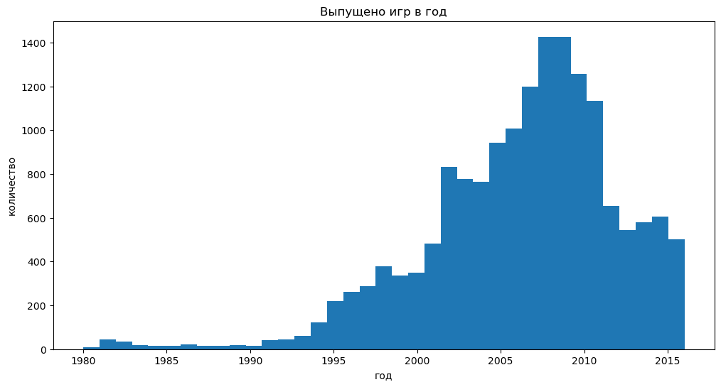

```python
# количество выпускаемых игр в год, гистограмма


games['year_of_release'].plot.hist(bins=37, figsize=(12, 6), title='Выпущено игр в год')
plt.xlabel('год')
plt.ylabel('количество');
```

Для простого прогнозирования продаж на следующий год данные за весь период не нужны, нужны только данные за несколько последних лет.

### Оценка изменения продаж игр по платформам

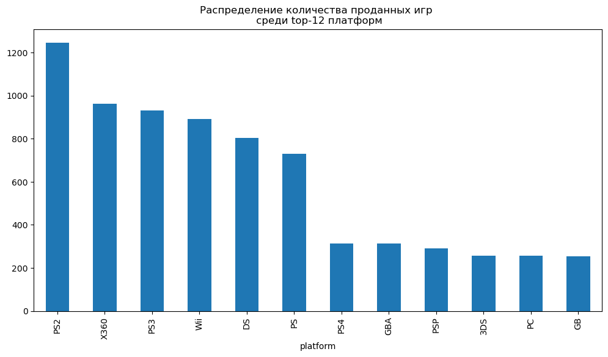

```python
np = 12 # количество n в top-n платформ

most_pop_pl = games.groupby('platform')['total_sales'].sum().sort_values(ascending=False)[:np]

# платформы с наибольшим количеством проданных копий игр
most_pop_pl.plot.bar(figsize=(12, 6), title=f'Распределение количества проданных игр \n среди top-{np} платформ');
```

Изменение продаж по годам в зависимости от платформы:

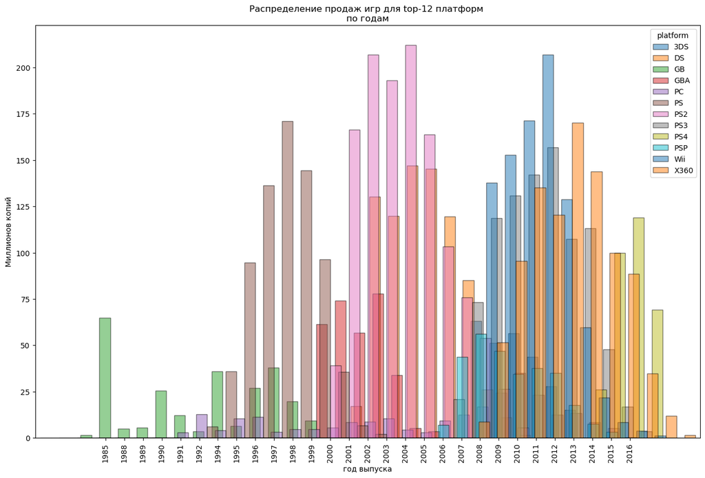

```python
#Общий график распределения продаж по годам среди top-12 платформ

gr_by_y_pl = games[games['platform'].isin(most_pop_pl.index)].groupby(['year_of_release', 'platform'])
gr_by_y_pl['total_sales'].sum().unstack().plot.bar(figsize=(16, 10), width=7, alpha=0.5,
                                                   xlabel=ru_name['year_of_release'],
                                                   ylabel='Миллионов копий',
                                                   title=f'Распределение продаж игр для top-{np} платформ \nпо годам',
                                                   edgecolor='black'
                                                  );
```

Распределение продаж по годам среди самых популярных игровых платформ:

```python
gr_by_pl_y = pd.DataFrame(
    games[games['platform'].isin(most_pop_pl.index)] # срез только популярных платформ
    .groupby(['platform', 'year_of_release'])['total_sales'].sum() # группировка общих продаж по двум параметрам
)
```

```python
# функция отображения 12 столбчатых диаграмм на одной решетке

def barplot_platforms(df, plist):
    fig, axes = plt.subplots(nrows=len(plist) // 3 + len(plist) % 3, ncols=3, figsize=(16, 16))
    axes = axes.flatten()

    for i in range(len(plist)):
        g = plist[i]
        df.loc[(g, )].plot.bar(
            width=0.9, ax=axes[i],
            xlabel=ru_name['year_of_release'],
            ylabel='Миллионов копий',
            title=f'Распределение продаж игр для платформы {g} \nпо годам'
        );

    plt.subplots_adjust(left=0, bottom=0, right=1, top=1, wspace=0.15, hspace=0.5)
```

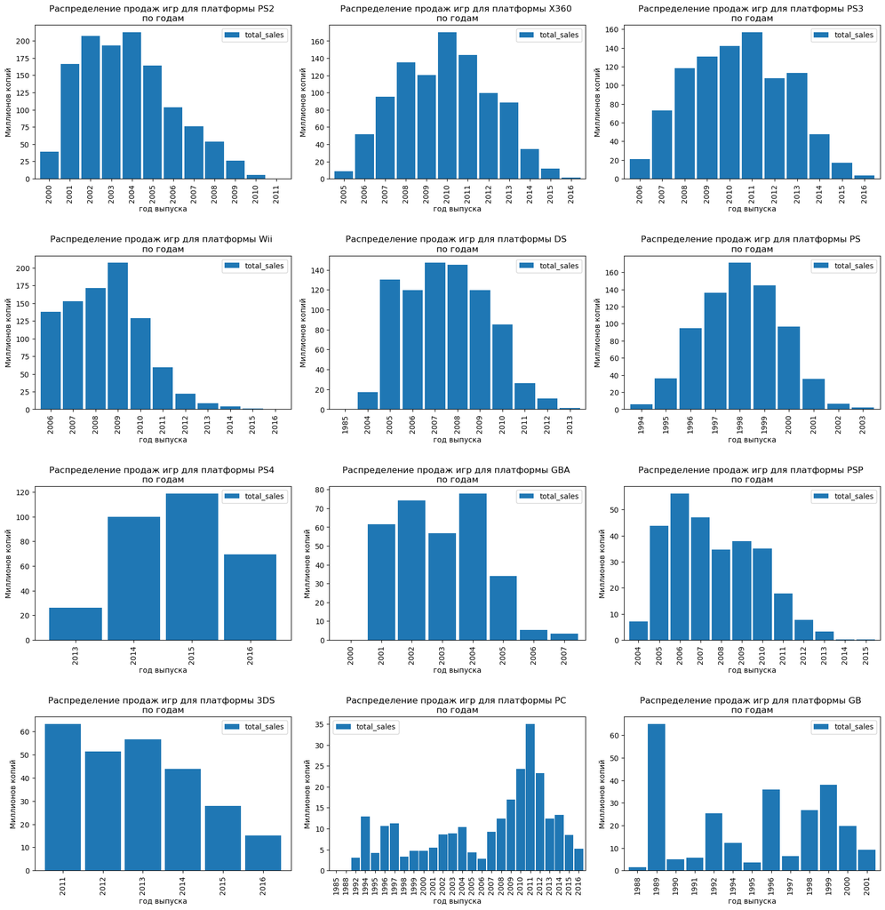

```python
barplot_platforms(gr_by_pl_y, most_pop_pl.index)
```

Платформа Nintendo DS существует только с 2004-го года, проверяю:

```python
games[(games['platform'] == 'DS') & (games['year_of_release'] < 2004)]
```

|  | name | platform | year_of_release | genre | na_sales | eu_sales | jp_sales | other_sales | critic_score | user_score | rating | rating_by_age | total_sales |
| --- | --- | --- | --- | --- | --- | --- | --- | --- | --- | --- | --- | --- | --- |
| 15957 | Strongest Tokyo University Shogi DS | DS | 1985 | Action | 0.0 | 0.0 | 0.02 | 0.0 | -1 | -1 | Unknown | -1 | 0.02 |

Интернет ничего не знает об игре с таким названием, в списках сёги игр для DS её тоже нет. Жанр неверен (сёги - это спортивная игра), продажи околонулевые, рейтинга нет. Удаляю:

```python
games = games.drop(15957)
```

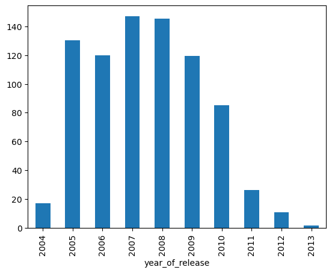

```python
games[games['platform'] == 'DS'].groupby('year_of_release')['total_sales'].sum().plot.bar();
```

### Оценка изменения продаж за актуальный период

Для оценки был выбран период в 3 года, с 2014 по 2016 г. Распределение продаж по годам среди актуальных игровых платформ:

```python
# датафрейм с распределением общих продаж по годам для каждой платформы, игры к которым выпускались после 2013

games_actual = games[games['year_of_release'] > 2013]

gr_by_pl_y_actual = pd.DataFrame(games_actual.groupby(['platform', 'year_of_release'])['total_sales'].sum())
```

```python
# список платформ, под которые выпускались игры после 2013

pl_actual = gr_by_pl_y_actual.index.get_level_values(0).unique()
pl_actual
```

```
Index(['3DS', 'PC', 'PS3', 'PS4', 'PSP', 'PSV', 'Wii', 'WiiU', 'X360', 'XOne'], dtype='object', name='platform')
```

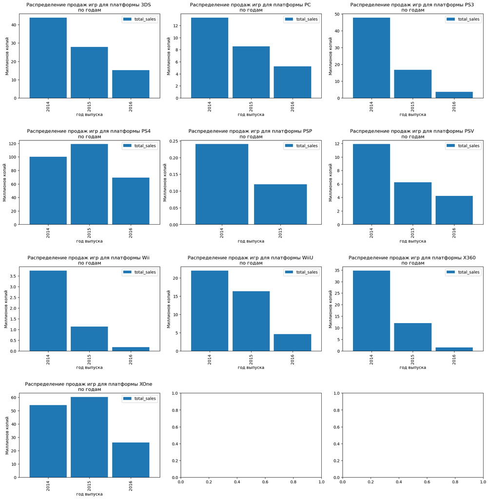

```python
# распределение продаж среди платформ с продажами после 2013

barplot_platforms(gr_by_pl_y_actual, pl_actual)
```

Среди платформ, под которые выпускаются игры после 2013-го у PSP вообще нет продаж в 2016-м году.

```python
# лидеры продаж за последний год

act_pl_df = gr_by_pl_y_actual.reset_index()
act_pl_2016 = act_pl_df[act_pl_df['year_of_release'] == 2016].sort_values(by='total_sales', ascending=False)
act_pl_2016['share'] = act_pl_2016['total_sales'] * 100 / act_pl_2016['total_sales'].sum()
act_pl_2016
```

|  | platform | year_of_release | total_sales | share |
| --- | --- | --- | --- | --- |
| 11 | PS4 | 2016 | 69.25 | 53.293828 |
| 28 | XOne | 2016 | 26.15 | 20.124673 |
| 2 | 3DS | 2016 | 15.14 | 11.651531 |
| 5 | PC | 2016 | 5.25 | 4.040326 |
| 22 | WiiU | 2016 | 4.60 | 3.540095 |
| 16 | PSV | 2016 | 4.25 | 3.270740 |
| 8 | PS3 | 2016 | 3.60 | 2.770509 |
| 25 | X360 | 2016 | 1.52 | 1.169771 |
| 19 | Wii | 2016 | 0.18 | 0.138525 |

По продажам в последний год лидируют платформы XOne и PS4 с большим отрывом (69,3 млн. копий, 53.3% рынка у PS4, 26,15 млн. и 20.1% рынка у XOne)

Визуальный анализ динамики на графиках показал, что в 2016 год падение продаж показывают все платформы, но это может быть следствием того, что данные за 2016 год неполны. Если ориентироваться на данные за 2015-й, рост продаж наблюдается у платформ PS4 и XOne, именно на этих платформах следует сосредоточиться разработчикам качественных и требовательных компьютерных игр. Как правило, игры на XOne легко переносятся на PC из-за схожей архитектуры, поэтому стоит обратить внимание и на эту платформу.

Если же разработчик сосредоточен на менее требовательных и более казуальных играх, то имеет смысл обратить внимание на такие платформы как 3DS и WiiU, которые представляют из себя портативные (ручные) консоли и до сих пор занимают весомую долю рынка (11,6 и 3,5%% соответственно).

### Постороение диаграмм размаха ("ящиков с усами") для глобальных продаж

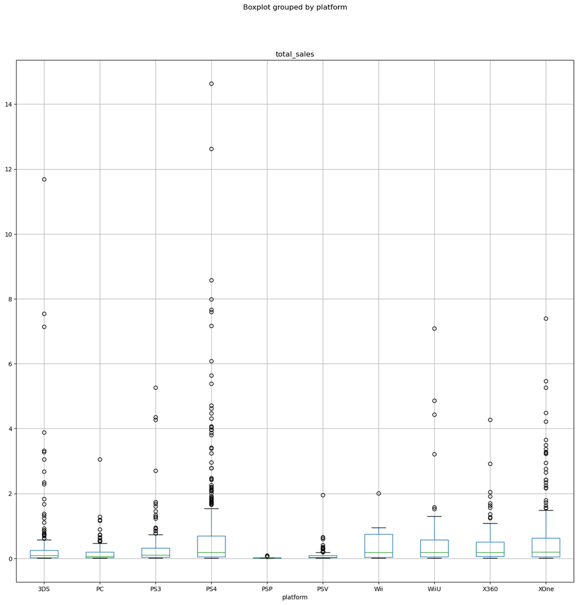

```python
games_actual.boxplot(column='total_sales', by='platform', figsize=(16, 16));
```

Проверяю на выбросы:

```python
games_actual[games_actual['total_sales'] > 6][['name', 'platform', 'total_sales']]
```

|  | name | platform | total_sales |
| --- | --- | --- | --- |
| 31 | Call of Duty: Black Ops 3 | PS4 | 14.63 |
| 42 | Grand Theft Auto V | PS4 | 12.62 |
| 47 | Pokemon Omega Ruby/Pokemon Alpha Sapphire | 3DS | 11.68 |
| 77 | FIFA 16 | PS4 | 8.58 |
| 87 | Star Wars Battlefront (2015) | PS4 | 7.98 |
| 92 | Call of Duty: Advanced Warfare | PS4 | 7.66 |
| 94 | FIFA 17 | PS4 | 7.60 |
| 96 | Super Smash Bros. for Wii U and 3DS | 3DS | 7.55 |
| 99 | Call of Duty: Black Ops 3 | XOne | 7.39 |
| 105 | Fallout 4 | PS4 | 7.17 |
| 108 | Pokemon Sun/Moon | 3DS | 7.14 |
| 110 | Mario Kart 8 | WiiU | 7.09 |
| 143 | FIFA 15 | PS4 | 6.08 |

У платформ 3DS, PS4, XOne, WiiU, PS3 и X360 наблюдаются значения продаж, экстремально далеко стоящие за границами основного распределения. Это не выбросы, а хиты продаж - игры из-за которых, во многом, покупают саму игровую платформу:

Диаграмы размаха в увеличенном масштабе:

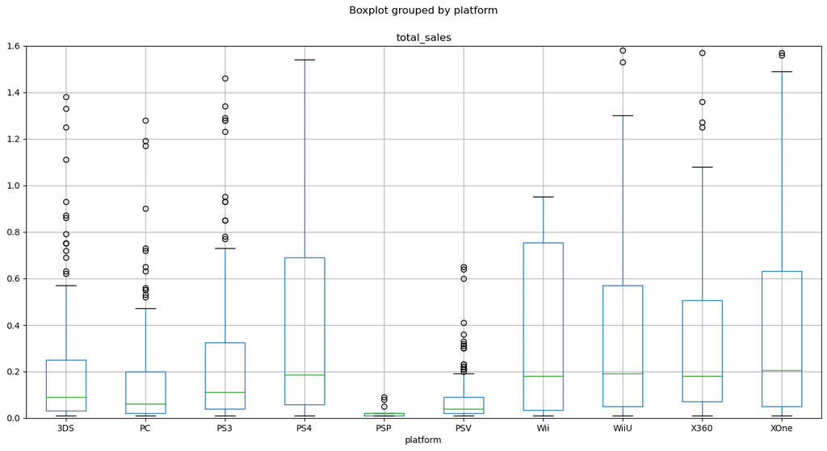

```python
lim_bxplt = games_actual.boxplot(column='total_sales', by='platform', figsize=(16, 8))
lim_bxplt.set_ylim(0, 1.6);
```

Из актуальных платформ наибольший разброс по глобальным продажам у PS4, Wii и XOne, наименьший - у платформ PSP, PSV, PC и 3DS. В целом распределения продаж у XOne, PS4 и Х360 похожи, но у PS4 есть несколько гораздо более успешно продаваемых игр, чем самые успешные на XOne.

Медианные значения глобальных продаж для одной игры у платформ PS4, XOne, X360, Wii и WiiU близки к отметки 0,2 млн. копий, у платформ 3DS и PS3 - к 0,1 млн. копий. У PC и PSV - к 0,05 млн.

В общем случае лучше ориентироваться на те платформы, у которых медианные продажи выше. Из актульных это XOne, PS4 и WiiU.

### Изучение влияния отзывов пользователей и критиков на продажи внутри одной популярной платформы

```python
# функция для вывода диаграмм разброса

def plot_scatter_actual(plf):
    fig, axes = plt.subplots(nrows=1, ncols=2, figsize=(14, 4))
    for i, n in enumerate(['critic_score', 'user_score']):
        games_actual[(games_actual[n] != -1) & (games_actual['platform'] == plf)].plot.scatter(
            x=n, y='total_sales', alpha=0.5, ax=axes[i],
            title=f'Разброс значений для платформы {plf}',
            xlabel=ru_name[n],
            ylabel=ru_name['total_sales']
        )
```

```python
# функция оформления расчета корреляций

def get_corr(plf):
    for n in ['critic_score', 'user_score']:
        corr = games_actual[(games_actual[n] != -1) & (games_actual['platform'] == plf)][[n, 'total_sales']].corr().iloc[0, 1]
        print(f"{plf}: корреляция между '{ru_name[n]}' и '{ru_name['total_sales']}': {corr:.3f}")
```

Для примера взята платформа PlayStation 4:

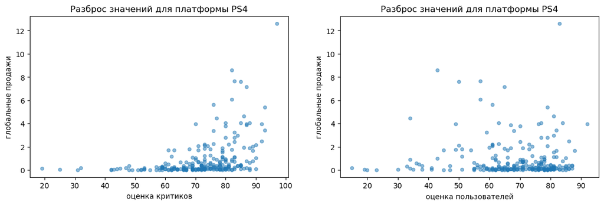

```python
plot_scatter_actual('PS4')
```

```python
get_corr('PS4')
```

```
PS4: корреляция между 'оценка критиков' и 'глобальные продажи': 0.403
PS4: корреляция между 'оценка пользователей' и 'глобальные продажи': -0.040
```

Между оценками критиков и глобальными продажами есть среднего уровня положительная линейная связь (коэфф. корр. 0,4), причем, судя по диаграмме рассеяния, связь тем выше, чем выше оценки критиков. С оценками пользователй такой связи параметр продаж не демонстрирует (коэфф. корр. -0,04).

##### сравнение с продажами на других платформах

Графики разброса для всех актуальных платформ, кроме PSP, у которой вообще не было продаж в 2016-м году:

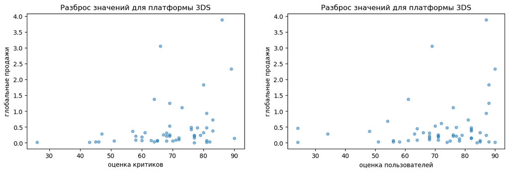

```
3DS: корреляция между 'оценка критиков' и 'глобальные продажи': 0.314
3DS: корреляция между 'оценка пользователей' и 'глобальные продажи': 0.215
```

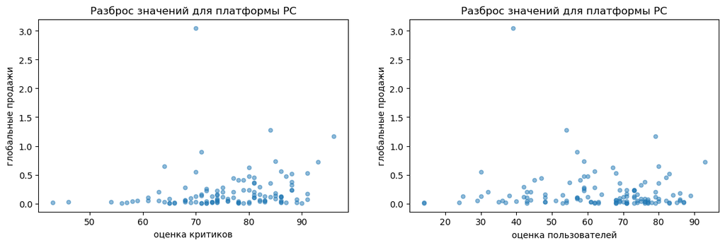

```
PC: корреляция между 'оценка критиков' и 'глобальные продажи': 0.175
PC: корреляция между 'оценка пользователей' и 'глобальные продажи': -0.072
```

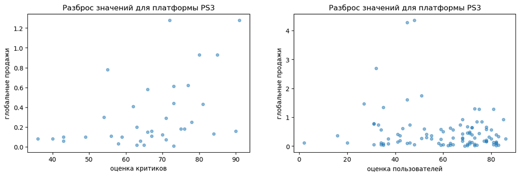

```
PS3: корреляция между 'оценка критиков' и 'глобальные продажи': 0.447
PS3: корреляция между 'оценка пользователей' и 'глобальные продажи': -0.167
```

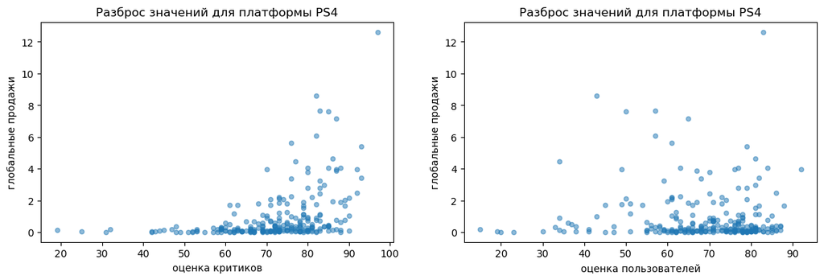

```
PS4: корреляция между 'оценка критиков' и 'глобальные продажи': 0.403
PS4: корреляция между 'оценка пользователей' и 'глобальные продажи': -0.040
```

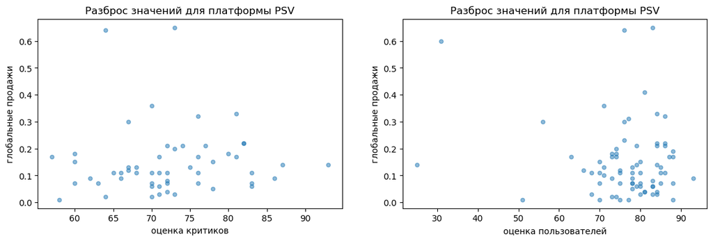

```
PSV: корреляция между 'оценка критиков' и 'глобальные продажи': 0.043
PSV: корреляция между 'оценка пользователей' и 'глобальные продажи': -0.168
```

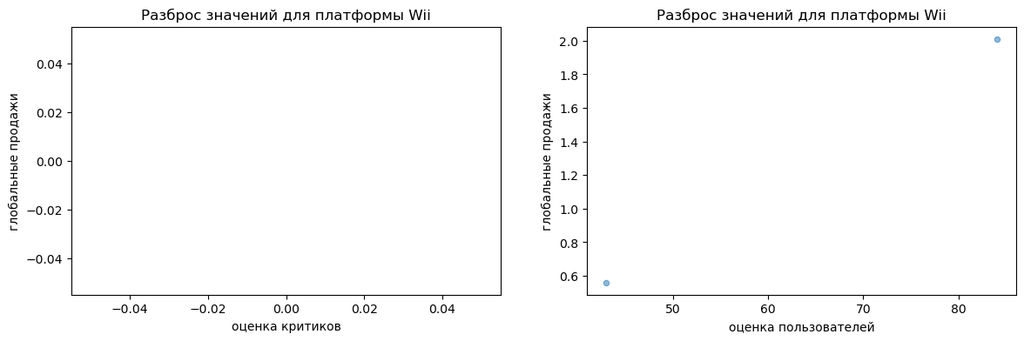

```
Wii: корреляция между 'оценка критиков' и 'глобальные продажи': nan
Wii: корреляция между 'оценка пользователей' и 'глобальные продажи': 1.000
```

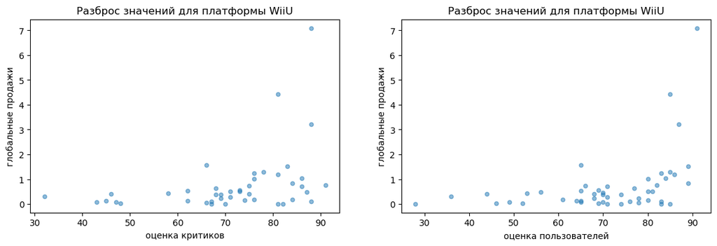

```
WiiU: корреляция между 'оценка критиков' и 'глобальные продажи': 0.370
WiiU: корреляция между 'оценка пользователей' и 'глобальные продажи': 0.408
```

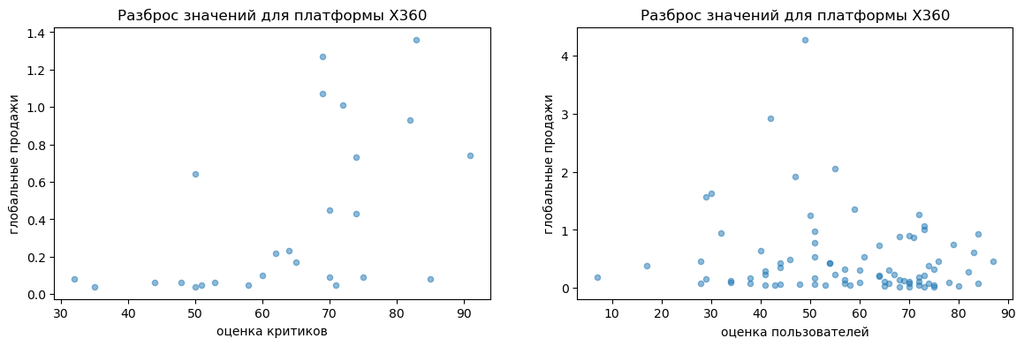

```
X360: корреляция между 'оценка критиков' и 'глобальные продажи': 0.526
X360: корреляция между 'оценка пользователей' и 'глобальные продажи': -0.138
```

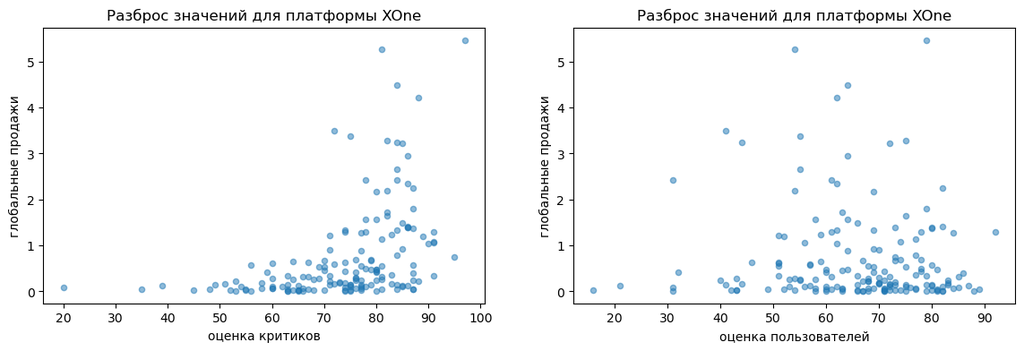

```
XOne: корреляция между 'оценка критиков' и 'глобальные продажи': 0.429
XOne: корреляция между 'оценка пользователей' и 'глобальные продажи': -0.070
```

```python
for plf in pl_actual.drop('PSP'):
    plot_scatter_actual(plf)
    plt.show()
    get_corr(plf)
    print()
```

По платформе Wii с наложенными условяими слишком мало данных (для `critic_score` вообще нет), поэтому корреляции и графики разброса по ней вышли странными или вовсе не получились. Поэтому в выводах эта платформа опущена.

```python
games_actual[(games_actual['critic_score'] != -1) & (games_actual['platform'] == 'Wii')]
```

|  | name | platform | year_of_release | genre | na_sales | eu_sales | jp_sales | other_sales | critic_score | user_score | rating | rating_by_age | total_sales |
| --- | --- | --- | --- | --- | --- | --- | --- | --- | --- | --- | --- | --- | --- |

##### общее распределение игр по жанрам

```python
games_actual.groupby('genre')['total_sales'].agg(['count', 'sum', 'mean', 'median']).sort_values(by='median', ascending=False)
```

| genre | count | sum | mean | median |
| --- | --- | --- | --- | --- |
| Shooter | 128 | 170.94 | 1.335469 | 0.515 |
| Sports | 161 | 109.48 | 0.680000 | 0.180 |
| Platform | 38 | 18.09 | 0.476053 | 0.140 |
| Fighting | 60 | 28.22 | 0.470333 | 0.125 |
| Role-Playing | 221 | 101.44 | 0.459005 | 0.110 |
| Simulation | 44 | 13.13 | 0.298409 | 0.100 |
| Action | 619 | 199.36 | 0.322068 | 0.090 |
| Misc | 113 | 37.55 | 0.332301 | 0.090 |
| Racing | 69 | 27.52 | 0.398841 | 0.090 |
| Strategy | 37 | 3.96 | 0.107027 | 0.060 |
| Puzzle | 14 | 2.21 | 0.157857 | 0.045 |
| Adventure | 185 | 17.55 | 0.094865 | 0.030 |

Для показательности построю диаграмму размаха:

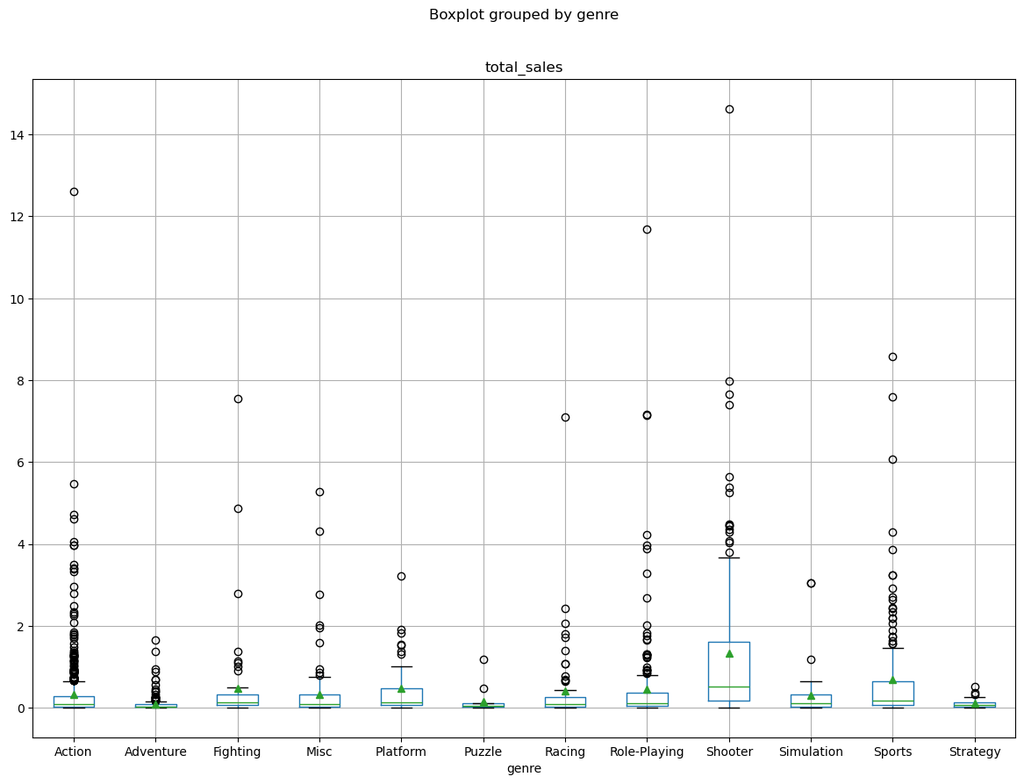

```python
games_actual.boxplot(column='total_sales', by='genre', figsize=(14, 10), showmeans=True);
```

На диаграмме видно, насколько асимметричны распределения. Это говорит о том, что медианные значения здесь для оценок будут более показательными, чем средние.

### Составление портрета пользователя каждого региона

##### самые популярные платформы (топ-5)

```python
regions = {'na_sales':'North America', 'eu_sales':'Europe', 'jp_sales':'Japan'}
pars = ['rlsd', 'sold (mln)', 'sold/rlsd', 'sold %'] # released (rlsd)

# функция группировки региональных данных по категории
def group_by_reg(cat, region):
    gbr_df = (games_actual.groupby(cat)[region]
            .agg(['count', 'sum', 'mean'])
            .sort_values(by='sum', ascending=False)
            .reset_index())
    gbr_df['%'] = gbr_df['sum'] * 100 / gbr_df['sum'].sum()
    if gbr_df.shape[0] > 5:
        nr = gbr_df.loc[5:, :].sum()
        gbr_df = gbr_df[:5].copy()
        nr[cat] = 'Other'
        gbr_df.loc[5] = nr
    gbr_df.columns = [cat]+pars
    return gbr_df

# функция склеивания откатегаризованных данных и отрисовки диаграмм
def regional_top(cat, draw_pies=True):
    full_table = pd.concat([group_by_reg(cat, 'na_sales'),
                            group_by_reg(cat, 'eu_sales'),
                            group_by_reg(cat, 'jp_sales')], axis=1)

    mi = pd.MultiIndex.from_frame(full_table)
    mi.names = [(r_name, p) for r_name in regions.values() for p in [cat]+pars]

    all_cat = mi.to_frame(index=False)


    if draw_pies:
        fig, axes = plt.subplots(nrows=1, ncols=3, figsize=(16, 8))
        regs = list(regions.values())
        for i, ax in enumerate(axes.flat):
            all_cat[[(regs[i], cat), (regs[i], 'sold (mln)')]].set_index((regs[i], cat)).plot.pie(
                y=(regs[i], 'sold (mln)'), legend=False, title=regs[i], autopct='%1.1f%%', ax=axes[i] )
        plt.subplots_adjust(left=0, bottom=0, right=1, top=1, wspace=0.1, hspace=0.5)

    return all_cat
```

|  | (North America, platform) | (North America, rlsd) | (North America, sold (mln)) | (North America, sold/rlsd) | (North America, sold %) | (Europe, platform) | (Europe, rlsd) | (Europe, sold (mln)) | (Europe, sold/rlsd) | (Europe, sold %) | (Japan, platform) | (Japan, rlsd) | (Japan, sold (mln)) | (Japan, sold/rlsd) | (Japan, sold %) |
| --- | --- | --- | --- | --- | --- | --- | --- | --- | --- | --- | --- | --- | --- | --- | --- |
| 0 | PS4 | 376 | 98.61 | 0.262261 | 34.714497 | PS4 | 376 | 130.04 | 0.345851 | 48.041968 | 3DS | 212 | 44.24 | 0.208679 | 47.523902 |
| 1 | XOne | 228 | 81.27 | 0.356447 | 28.610153 | XOne | 228 | 46.25 | 0.202851 | 17.086597 | PS4 | 376 | 15.02 | 0.039947 | 16.134923 |
| 2 | X360 | 111 | 28.30 | 0.254955 | 9.962684 | PS3 | 219 | 25.54 | 0.116621 | 9.435496 | PSV | 295 | 14.54 | 0.049288 | 15.619293 |
| 3 | 3DS | 212 | 22.64 | 0.106792 | 7.970147 | PC | 151 | 17.97 | 0.119007 | 6.638836 | PS3 | 219 | 11.22 | 0.051233 | 12.052852 |
| 4 | PS3 | 219 | 22.05 | 0.100685 | 7.762445 | 3DS | 212 | 16.12 | 0.076038 | 5.955372 | WiiU | 73 | 7.31 | 0.100137 | 7.852616 |
| 5 | Other | 543 | 31.19 | 0.510720 | 10.980075 | Other | 503 | 34.76 | 0.567107 | 12.841732 | Other | 514 | 0.76 | 0.029817 | 0.816414 |

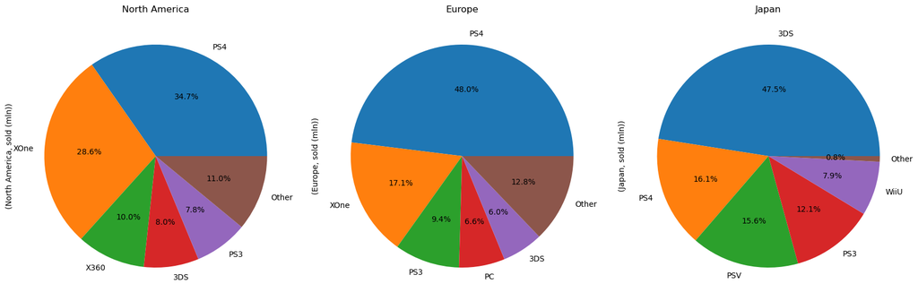

```python
# топ-5 платформ для каждого региона (отсортировано по общему количеству проданных копий (sum))

regional_top('platform')
```

В Северной Америке и Европе игроки предпочитают консоли PS4 и XOne, а в Японии в лидерах продаж портативная 3DS, затем PS4

Если же смотреть на отношение проданных копий игр к количеству самих игр, то в С. Америке в лидерах XOne, в Европе лучше всего продаются игры на PS4, а в Японии для 3DS.

##### самые популярные жанры (топ-5)

|  | (North America, genre) | (North America, rlsd) | (North America, sold (mln)) | (North America, sold/rlsd) | (North America, sold %) | (Europe, genre) | (Europe, rlsd) | (Europe, sold (mln)) | (Europe, sold/rlsd) | (Europe, sold %) | (Japan, genre) | (Japan, rlsd) | (Japan, sold (mln)) | (Japan, sold/rlsd) | (Japan, sold %) |
| --- | --- | --- | --- | --- | --- | --- | --- | --- | --- | --- | --- | --- | --- | --- | --- |
| 0 | Shooter | 128 | 79.02 | 0.617344 | 27.818067 | Action | 619 | 74.68 | 0.120646 | 27.589774 | Role-Playing | 221 | 31.16 | 0.140995 | 33.472983 |
| 1 | Action | 619 | 72.53 | 0.117173 | 25.533338 | Shooter | 128 | 65.52 | 0.511875 | 24.205704 | Action | 619 | 29.58 | 0.047787 | 31.775701 |
| 2 | Sports | 161 | 46.13 | 0.286522 | 16.239527 | Sports | 161 | 45.73 | 0.284037 | 16.894488 | Fighting | 60 | 6.37 | 0.106167 | 6.842840 |
| 3 | Role-Playing | 221 | 33.47 | 0.151448 | 11.782722 | Role-Playing | 221 | 28.17 | 0.127466 | 10.407123 | Misc | 113 | 5.61 | 0.049646 | 6.026426 |
| 4 | Misc | 113 | 15.05 | 0.133186 | 5.298176 | Racing | 69 | 14.13 | 0.204783 | 5.220186 | Shooter | 128 | 4.87 | 0.038047 | 5.231496 |
| 5 | Other | 447 | 37.86 | 0.675692 | 13.328170 | Other | 491 | 42.45 | 0.690764 | 15.682725 | Other | 548 | 15.50 | 0.280609 | 16.650553 |

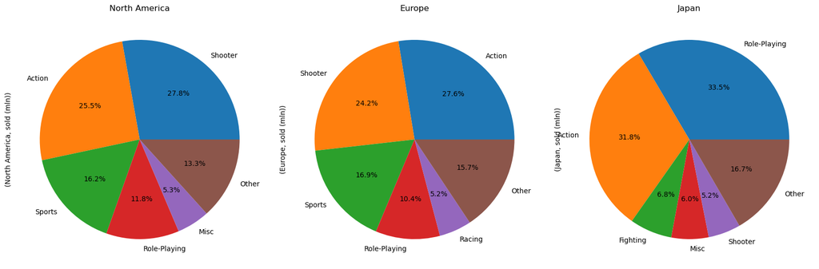

```python
regional_top('genre')
```

По количеству проданных копий в С. Америке и Европе лучше всего продаются боевики, спортивные игры и стрелялки, а в Японии - ролевые игры, боевики и файтинги.

Соотношение проданных копий к количеству выпущенных игр для С. Америки и Европы выше всего у стрелялок и спортивных игр, для Японии - у ролевых игр и файтингов.

##### влияние ESRB на продажи в отдельном регионе

Доля игр определенного возрастного рейтинга в общем количестве проданных в регионе игр:

|  | (North America, rating) | (North America, rlsd) | (North America, sold (mln)) | (North America, sold/rlsd) | (North America, sold %) | (Europe, rating) | (Europe, rlsd) | (Europe, sold (mln)) | (Europe, sold/rlsd) | (Europe, sold %) | (Japan, rating) | (Japan, rlsd) | (Japan, sold (mln)) | (Japan, sold/rlsd) | (Japan, sold %) |
| --- | --- | --- | --- | --- | --- | --- | --- | --- | --- | --- | --- | --- | --- | --- | --- |
| 0 | M | 265 | 96.42 | 0.363849 | 33.943533 | M | 265 | 93.44 | 0.352604 | 34.520467 | Unknown | 749 | 56.90 | 0.075968 | 61.123644 |
| 1 | Unknown | 749 | 64.72 | 0.086409 | 22.783919 | Unknown | 749 | 58.95 | 0.078705 | 21.778484 | T | 271 | 14.78 | 0.054539 | 15.877108 |
| 2 | E | 219 | 50.74 | 0.231689 | 17.862423 | E | 219 | 58.06 | 0.265114 | 21.449682 | E | 219 | 8.94 | 0.040822 | 9.603609 |
| 3 | T | 271 | 38.95 | 0.143727 | 13.711892 | T | 271 | 34.07 | 0.125720 | 12.586818 | M | 265 | 8.01 | 0.030226 | 8.604576 |
| 4 | E10+ | 185 | 33.23 | 0.179622 | 11.698233 | E10+ | 185 | 26.16 | 0.141405 | 9.664549 | E10+ | 185 | 4.46 | 0.024108 | 4.791062 |

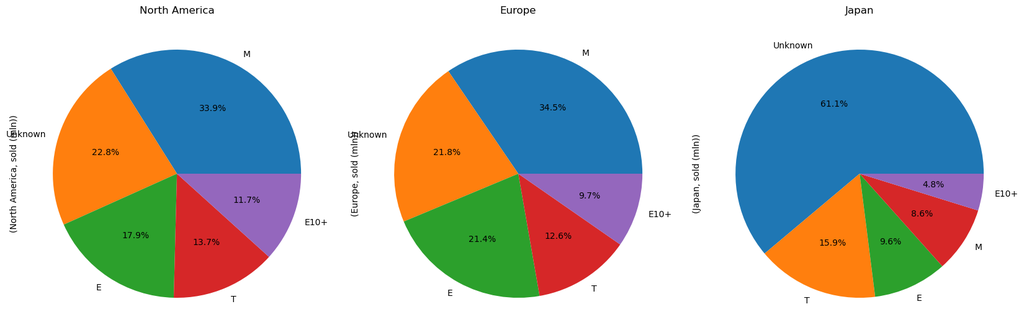

```python
regional_top('rating')
```

```python
# определяю средевзвешенный возрастной рейтинг для каждого региона среди игр, у которых есть рейтинг ESRB

for reg in regions:
    filtered = games_actual[games_actual['rating_by_age'] != -1]
    mean_age_r = (filtered[reg] * filtered['rating_by_age']).sum() / filtered[reg].sum()
    print(f'Средневзвешенный возрастной рейтинг для колонки {reg} составляет {mean_age_r:.2f} лет.')
```

```
Средневзвешенный возрастной рейтинг для колонки na_sales составляет 11.99 лет.
Средневзвешенный возрастной рейтинг для колонки eu_sales составляет 11.65 лет.
Средневзвешенный возрастной рейтинг для колонки jp_sales составляет 11.05 лет.
```

По диаграммам и таблице видно, что распределение игр по рейтингам в общей доле проданных очень схоже между регионами С. Америки и Европы и отличается порой проценты. В Японии же более склонны покупать игры, которые вообще не имеют маркировки по системе ESRB, таких игр целый 61%, (в С. Америка - 23%, в Европе - 22%) это существенно различие в предпочтениях. Среди тех игр, которые имеют ESRB рейтинг в Японии большее предпочтение отдают играм с "подростковым" рейтингом (T) и меньшее - со "зрелым" рейтингом (M), в С. Америке и Европе - наоборот.

По средневзвешенному возрастному рейтингу в С. Америке продаются в среднем более "взрослые" игры (рейтинг 11,99 год), чуть меньший рейтинг в Европе (11,65), и наименьший в Японии (11,05 года).

### Выводы из исследовательского анализа данных:

Для простого прогнозирования продаж на следующий год данные за весь период не нужны, были взятые данные за период с 2014-го года.

В ходе проведения исследовательского анализа данных было выяснено:

##### Региональный портрет пользователя:

- В Северной Америке пользователи предпочитают консоли PS4 и XOne. По отношению проданных копий игр к количеству самих игр здесь в лидерах XOne. По количеству проданных копий в С. Америке лучше всего продаются боевики, спортивные игры и стрелялки. Соотношение проданных копий к количеству выпущенных игр для С. Америки выше всего у стрелялок и спортивных игр. Распределения игр по рейтингам между регионами С. Америки и Европы в общей доле проданных очень схожи - предпочтение отдается играм с рейтингами Е, T и М. По средневзвешенному возрастному рейтингу в С. Америке продаются в среднем более "взрослые" игры (11,99), что выше и японского и европейского.
- В Европе больше предпочтение отдают разным консолям марки PS4. Если смотреть на отношение проданных копий игр к количеству самих игр, в Европе лучше всего продавались игры на PS4. По количеству проданных копий в Европе лучше всего продаются боевики, спортивные игры и стрелялки (прямо как С. Америке). Соотношение проданных копий к количеству выпущенных игр для Европы выше всего у стрелялок и спортивных игр. Средневзвешенный возрастной рейтинг в Европе (11,65), что выше, чем в Японии (11,05), но ниже, чем С. Америке (11,99).
- В Японии в лидерах продаж портативная 3DS, затем идет PS4. По отношению проданных копий игр к количеству самих игр в Японии лидирует также 3DS. Исходя из количества проданных копий в Японии лучше всего продаются ролевые игры, боевики и файтинги. Лучшее соотношение проданных копий к количеству выпущенных игр для Японии у ролевых игр и файтингов. В Японии более склонны покупать игры, которые вообще не имеют маркировки по системе ESRB, таких игр целый 61%, (в С. Америка - 23%, в Европе - 22%) это существенно различие в предпочтениях. Среди игр, которые имеют ESRB рейтинг в Японии большее предпочтение отдают играм с "подростковым" рейтингом (T) и меньшее - со "зрелым" рейтингом (M) Средневзвешенный возрастной рейтинг в Японии наименьший из представленых регионов (11,05 года)

## Проверка гипотез

Здесь и дальше:

$H_0$ - нулевая гипотеза;  
$H_a$ - альтернативная гипотеза;  
$\alpha$ - уровень значимости.

### Утверждение 1: Cредние пользовательские рейтинги платформ Xbox One и PC одинаковые

Формулировка гипотез:

$\mu_{xo}$ - средний пользовательский рейтинг Xbox One;  
$\mu_{pc}$ - средний пользовательский рейтинг PC;

$H_0: \mu_{xo} = \mu_{pc}$  
$H_a: \mu_{xo} \neq \mu_{pc}$

$\alpha = 5\%$

Уровень значимости $\alpha$ = 5% был взят, потому что это стандартный у.з. в тестах подобного рода.

Для проверки гипотез применяется t-критерий Стьюдента и метод оценки независимых выборок с разной дисперсией. t-критерий выбран из-за пригодности для оценки гипотез о равенстве средних для подобного вида распределений методом нахождения p-value. Метод оценки независимых выборок выбран исходя из предположения, что оценки играм в разных жанрах давались независимо.

Так как платформы разные, оценки давались независимо и разными игрокам - нет основания предполагать одинаковую дисперсию в данных (`equal_var=False`).

```python
xo_ur = games_actual[(games_actual['platform'] == 'XOne') & (games_actual['user_score'] != -1)]['user_score']
pc_ur = games_actual[(games_actual['platform'] == 'PC') & (games_actual['user_score'] != -1)]['user_score']

alpha = 0.05

results = stats.ttest_ind(xo_ur, pc_ur, equal_var=False)
print(f'P-value: {results.pvalue:.3f}')

if results.pvalue < alpha:
    print('Нулевая гипотеза отвергается')
else:
    print('Нулевую гипотезу отвергнуть нельзя')
```

```
P-value: 0.116
Нулевую гипотезу отвергнуть нельзя
```

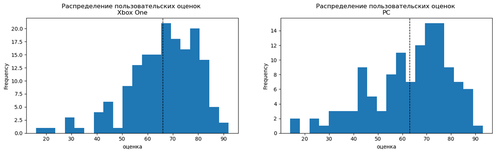

```python
# иллюстрация на данных по игровым платформам

fig, axes = plt.subplots(nrows=1, ncols=2, figsize=(16, 4))
xo_ur.plot.hist(bins=20, grid=False, ax=axes[0], title="Распределение пользовательских оценок \nXbox One")
pc_ur.plot.hist(bins=20, grid=False, ax=axes[1], title="Распределение пользовательских оценок \nPC")
axes[0].axvline(xo_ur.mean(), color='k', linestyle='dashed', linewidth=1)
axes[1].axvline(pc_ur.mean(), color='k', linestyle='dashed', linewidth=1)
axes[0].set_xlabel('оценка')
axes[1].set_xlabel('оценка');
```

На графиках видно, что средние действительно лежат недалеко друг от друга.

### Утверждение 2: Cредние пользовательские рейтинги жанров Action и Sports разные

Формулировка гипотез:

$\mu_a$ - средний пользовательский рейтинг action-игр;  
$\mu_s$ - средний пользовательский рейтинг игр в жанре sport;

$H_0: \mu_{a} = \mu_{s}$  
$H_a: \mu_{a} \neq \mu_{s}$

$\alpha = 1\%$

Здесь исходное утверждение, которое нуждается в проверке, соответствует **альтернативной гипотезе, которая будет принята, если будет отброшена нулевая!**

Для проверки гипотез применяется t-критерий Стьюдента и метод оценки независимых выборок с разной дисперсией. t-критерий выбран из-за пригодности для оценки гипотез о равенстве средних для подобного вида распределений методом нахождения p-value. Метод оценки независимых выборок выбран исходя из предположения, что оценки играм в разных жанрах давались независимо.

Так как жанры разные, оценки давались независимо и разными игрокам - нет основания предполагать одинаковую дисперсию в данных (`equal_var=False`).

```python
a_ur = games_actual[(games_actual['genre'] == 'Action') & (games_actual['user_score'] != -1)]['user_score']
s_ur = games_actual[(games_actual['genre'] == 'Sports') & (games_actual['user_score'] != -1)]['user_score']

alpha = 0.01

results = stats.ttest_ind(a_ur, s_ur, equal_var=False)
print(f'P-value: {results.pvalue:.6f}')

if results.pvalue < alpha:
    print('Нулевая гипотеза отвергается')
else:
    print('Нулевую гипотезу отвергнуть нельзя')
```

```
P-value: 0.000000
Нулевая гипотеза отвергается
```

На уровне значимости $\alpha$ = 1% отвергается нулевая гипотеза о равенстве среднего пользовательского рейтинга action-игр и sport-игр ($H_0: \mu_{a} = \mu_{s}$), то есть подтверждается утверждение, что средние пользовательские оценки жанров Action и Sport разные.

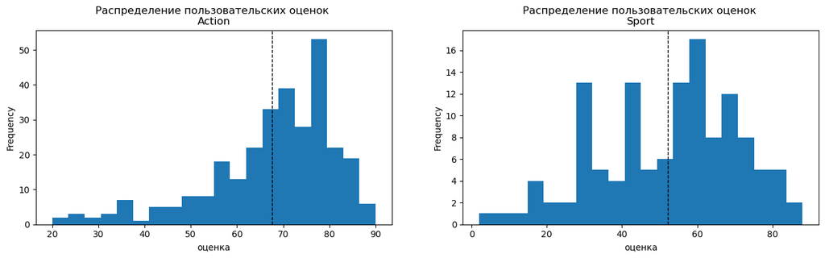

```python
# иллюстрация на данных по жанрам

fig, axes = plt.subplots(nrows=1, ncols=2, figsize=(16, 4))
a_ur.plot.hist(bins=20, grid=False, ax=axes[0], title="Распределение пользовательских оценок \nAction")
s_ur.plot.hist(bins=20, grid=False, ax=axes[1], title="Распределение пользовательских оценок \nSport")
axes[0].axvline(a_ur.mean(), color='k', linestyle='dashed', linewidth=1)
axes[1].axvline(s_ur.mean(), color='k', linestyle='dashed', linewidth=1)
axes[0].set_xlabel('оценка')
axes[1].set_xlabel('оценка');
```

Заметно, что средние значения разнятся сильно.

### Выводы по проверке гипотез:

Для проверки гипотез был применен t-критерий Стьюдента и метод оценки независимых выборок с разной дисперсией на нём основанный. t-критерий был выбран из-за пригодности для оценки гипотез о равенстве средних для подобного вида распределений методом нахождения p-value. Метод оценки независимых выборок `scipy.stats.ttest_ind()` выбран исходя из предположения, что оценки играм в разных жанрах давались независимо: так как платформы и жанры были выбраны разные, а оценки давались разными игроками, нет оснований предполагать зависимость или одинаковую дисперсию в данных, потому был также выбран параметр `equal_var=False`.

## Общий вывод

В ходе исследовательской работы были получены следующие результаты и выводы:

- Из самых популярных жанров (боевиков, стрелялок и спортивных игр) самые высокие медианные значения продаж на актуальных данных (2014-2016) у стрелялок, поэтому рекомендуется сосредоточиться на этом жанре.
- Ориентироваться лучше на платформы XOne (и PC в случае выбора XOne) и PS4 для глобального или западного рынка, и на платформы 3DS и PS4 для японского. XOne и PS4 выпущены в 2013-м году и полностью потеряют актуальность только к 2022-23гг. 3DS потеряет актульность к 2020-21гг.
- Обычно у стрелялок рейтинг М из-за наличия в них убийств и кровавых сцен. Если бы можно было добиться рейтинга T, при этом не потеряв интереса пользователей, потенциальная аудитория игры существенно бы возросла (пример - Fortnite).
- Связи между оценками пользователей и продажами на XOne и PS4 практически нет, поэтому при выборе этих платформ лучше ориентироваться на мнение критиков, с которыми у продаж есть положительная корреляция (чем выше оценка, тем выше корреляция). Для платформы 3DS и оценки критиков, и оценки пользователей важны, но в меньшей степени.

### Заключение

- В рамках данного исследовательского проекта предоставленные данные о продажах игр были проанализированы и обработаны таким образом, что это позволяет их считать подготовленными к дальнейшему предиктивному анализу.
- Также данное исследование выявило тенденции и закономерности в данных, позволяющие сегментировать потенциальный рынок и подобрать для продвижения с помощью рекламной кампании такое игровое решение, которое будет с точки зрения заказчика оптимальным по параметрам: жанра, региона, игровой платформы и возрастной группы ЦА.